# Synthetic: common road and event records

## Source and preparation

This generated fixture has 48 roads, twelve hourly frames and eighteen events. It tests reciprocal paths, two named regions, unassigned records, absent context and unspecified units. Its numbers and coordinates do not describe observations.

## Data preparation

`data/source.rds` contains the selected source-level records and supplied geometry. `prepare.R` converts them to the common input without downloading data. Its executed implementation appears in Appendix A. The generated `data/input.rds` is then read by the common package.

```r
library(bdynets)
source("prepare.R")
prepared_file <- prepare_example(".")
x <- read_traffic(prepared_file)
input <- readRDS(prepared_file)
index <- match(params$time_label,sub("^.* ","",x$time_labels))
stopifnot(!is.na(index))
```

The map starts at 08:00 and covers 60 minutes. The default 08:00 is a demonstration selection, not a maximum-based selection. Numeric seconds and displayed labels retain the supplied source clock; they do not establish a UTC offset.

```r
stopifnot(identical(x$unit,"unit unspecified"),is.null(x$basemap),
          sum(is.na(x$values))==7L,nrow(x$events)==18L)
knitr::kable(data.frame(Statistic=c("Roads","Frames","Supplied flow rows","Expected cells","Observed cells","Missing cells","Event starts"),
 Value=c(nrow(x$roads),length(x$times),nrow(input$flow),length(x$values),sum(!is.na(x$values)),sum(is.na(x$values)),nrow(x$events))))
```

| Statistic | Value |
| --- | --- |
| Roads | 48 |
| Frames | 12 |
| Supplied flow rows | 574 |
| Expected cells | 576 |
| Observed cells | 569 |
| Missing cells | 7 |
| Event starts | 18 |

Five explicit NA records and two omitted pairs create seven missing cells. Zero remains observed. Descriptive direction, lane and speed-limit fields do not choose a plotting rule.

## Combined roads and events

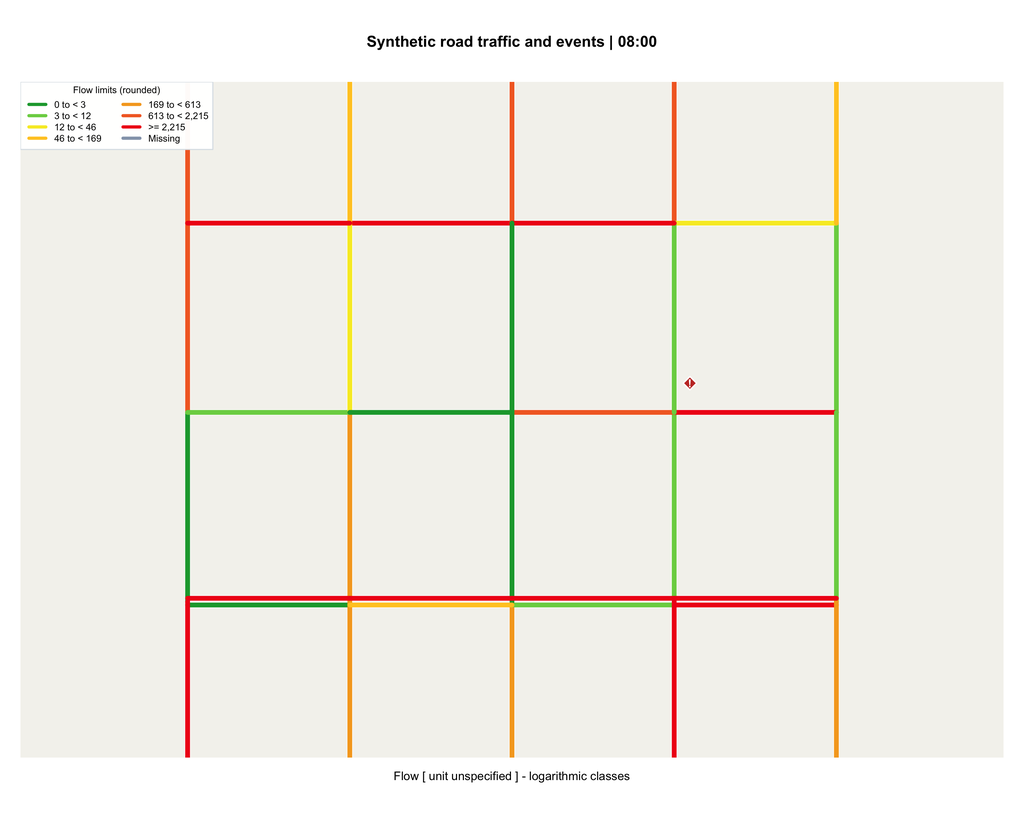

Generated roads and reported-start-style point records at the selected hour, using the same common plotting interface.

```r
plot(x,index=index)
```

```r
knitr::kable(traffic_summary(x,index=index),digits=2,caption="Selected-hour statistics")
```

Selected-hour statistics

| frame | time | roads | available | missing | zero | minimum | median | mean | p95 | maximum | events |
| --- | --- | --- | --- | --- | --- | --- | --- | --- | --- | --- | --- |
| 9 | 08:00 | 48 | 48 | 0 | 2 | 0 | 388.5 | 2162.27 | 7993.6 | 7999 | 1 |

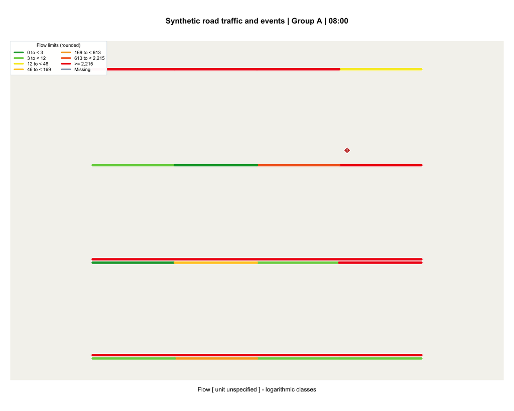

The supplied Group A selection retains the full input’s class thresholds.

```r
plot(x,index=index,region="Group A")
```

Empty region labels remain in the all-record scope. Events keep their supplied coordinates and belong to their half-open interval.

## Figure and data export

The common `traffic_export()` interface writes PNG/PDF maps and applicable trends, exact selected records, summary and trend tables, source metadata, input/output MD5 checksums and session information. `selected-frame.rds` retains the full input’s color thresholds and unit for inspection; it is not a new input bundle. Existing output directories are refused. The report parameter `export` defaults to false, so normal rendering creates no export folder.

```r
if(params$export) {
  label <- gsub("[^[:alnum:]_-]+","-",x$time_labels[index])
  traffic_export(x,file.path(params$export_dir,label),index=index,
    input_files=c(source="data/source.rds",prepared="data/input.rds"))
}
```

## Appendix A: preparation implementation

The following code is the source-to-input transformation executed from `prepare.R`. The input cache supplies all objects used by this function.

```r
prepare_example <- function(base=".", source_file="data/source.rds", output_file="data/input.rds") {
  base <- normalizePath(base, mustWork=TRUE)
  source_path <- file.path(base, source_file)
  s <- readRDS(source_path)
  stopifnot(identical(s$schema, "synthetic-records-v1"))
  roads <- s$roads; flow <- s$flow; events <- s$events
  roads$road_id <- as.character(roads$road_id)
  flow$road_id <- as.character(flow$road_id)
  s$settings$provenance$preparation_check <- list(supplied_flow_rows=nrow(flow),
    omitted_pairs=nrow(roads)*length(s$settings$times)-nrow(flow),
    explicit_missing=sum(is.na(flow$flow)))
  input <- c(list(schema="trafficmap-input-v1", roads=roads, flow=flow, events=events), s$settings)
  input$provenance$source_cache <- list(file=basename(source_file),
    bytes=unname(file.info(source_path)$size), md5=unname(tools::md5sum(source_path)), schema=s$schema)
  stopifnot(!anyDuplicated(roads$road_id), all(flow$road_id %in% roads$road_id),
            !anyDuplicated(flow[c("road_id", "time")]),
            all(is.na(flow$flow) | (is.finite(flow$flow) & flow$flow >= 0)))
  bdynets::traffic_data(roads=roads, flow=flow, events=events,
    times=input$times, time_labels=input$time_labels, interval_seconds=input$interval_seconds,
    unit=if(is.null(input$unit)) "unit unspecified" else input$unit,
    basemap=input$basemap)
  output <- file.path(base, output_file)
  dir.create(dirname(output), recursive=TRUE, showWarnings=FALSE)
  saveRDS(input, output, compress="xz", version=3)
  invisible(output)
}
if(sys.nframe()==0L) {
  script <- sub("^--file=", "", grep("^--file=", commandArgs(FALSE), value=TRUE))
  if(length(script)!=1L) stop("Rscript entrypoint is required")
  if(!file.exists(script)) script <- gsub("~+~", " ", script, fixed=TRUE)
  prepare_example(dirname(normalizePath(script, mustWork=TRUE)))
  cat("Prepared data/input.rds\n")
}
```

## Appendix B: verification and runtime

```r
knitr::kable(data.frame(Check=names(input$provenance$preparation_check),
  Value=unlist(input$provenance$preparation_check)),caption="Executed preparation checks")
```

Executed preparation checks

|  | Check | Value |
| --- | --- | --- |
| supplied_flow_rows | supplied_flow_rows | 574 |
| omitted_pairs | omitted_pairs | 2 |
| explicit_missing | explicit_missing | 5 |

```r
knitr::kable(data.frame(File=c("source.rds","input.rds"),
  Bytes=unname(file.info(c("data/source.rds","data/input.rds"))$size),
  MD5=unname(tools::md5sum(c("data/source.rds","data/input.rds")))),
  caption="Actual bundled files")
```

Actual bundled files

| File | Bytes | MD5 |
| --- | --- | --- |
| source.rds | 5084 | 12367dbf2d4072987066bad4ba181ebb |
| input.rds | 5172 | c2ecf93b56e9f73b55e48cb9f1f9b4a2 |

[session information not shown]